# Tutorial 8: Genomic Selection & Van Raden Models (2)

QGM Team

17:07:33 on 04 February, 2022

# 1 Introduction

In the last Tutorial we constructed Van Raden genomic relationship matrices and ran a genomic evaluation in `asreml()`. In this tutorial we will look at extracting the estimates of marker effects and see how good they were - we have the luxury of knowing the true values. We should remember that in this simulated data all the loci are unlinked and real data is more challenging.

We will be examining the distinctions between VR1 and VR2 and seeing how to move between marker effects and EBVs and using the true values of substitution effects to explore the outcomes of the analysis. In the first part we will repeat Tutorial 7 as quickly as possible. (The data used is the same but file names have had the ‘7’ replaced by ‘8’, but I still use ‘t7’ for data frame names.)

```r
library("asreml")
```

# 2 QGM functions: old and new

We add an extra function below called `qgm_solve()` which inverts a (co)variance matrix (i.e. a symmetric positive definite matrix) quicker than the standard `solve()` in R (about half the time, and with big matrices this can help!).

```r
source("qgm_helpers_t8.R")
```

# 3 Reading genotypes

Same genotypes as Tutorial 7.

```r
t7gen <- read.csv(file="rgen8.csv",header=TRUE,na.strings=c("NA"))
loci <- c(2:501)
aaf <- qgm_counts_to_freq(t7gen[,loci])
```

# 4 Calculating relationship matrices

## 4.1 Van Raden 1

```r
W1 <- qgm_vr1_to_W(t7gen[,loci],t7gen$id,colnames(t7gen[,loci]))
aaf <- qgm_counts_to_freq(t7gen[,loci])
cc <- sum(2.*aaf*(1.-aaf))
G1 <- qgm_W_to_G(W1,cc)
G1 <- G1 + 0.001*diag(nrow(G1))
```

## 4.2 Van Raden 2

```r
W2 <- qgm_vr2_to_W(t7gen[,loci],t7gen$id,colnames(t7gen[,loci]))
G2 <- qgm_W_to_G(W2,length(loci))
G2 <- G2 + 0.001*diag(nrow(G2))
```

# 5 Reading the data

Same data as Tutorial 7.

```r
t7dat <- read.csv(file="rdat8.csv",header=TRUE,na.strings=c("NA"))
t7dat$jid <- t7dat$id # a duplicate for future use
t7dat$id <- factor(t7dat$id,ordered=TRUE) # the factor
```

# 6 Fitting the models

## 6.1 Van Raden 1

```r
asr7_1 <- asreml(fixed= phe ~ 1, random= ~vm(id,G1), residual= ~idv(units), data= t7dat )
```

```
## Online License checked out Fri Feb  4 17:07:36 2022
## Model fitted using the sigma parameterization.
## ASReml 4.1.0 Fri Feb  4 17:07:36 2022
##           LogLik        Sigma2     DF     wall    cpu
##  1      -390.581           1.0     99 17:07:36    0.0
##  2      -290.709           1.0     99 17:07:36    0.0
##  3      -180.696           1.0     99 17:07:36    0.0
##  4      -104.232           1.0     99 17:07:36    0.0
##  5       -62.888           1.0     99 17:07:36    0.0
##  6       -50.762           1.0     99 17:07:36    0.0
##  7       -48.767           1.0     99 17:07:36    0.0
##  8       -48.671           1.0     99 17:07:36    0.0
##  9       -48.670           1.0     99 17:07:36    0.0
```

```r
qgm_summary(asr7_1)
```

```
## [1] "CONVERGENCE"
## [1] "TRUE with logL = -48.6702806082354"
##
## [1] "VARIANCE COMPONENTS"
##             component std.error   z.ratio bound %ch
## vm(id, G1)  0.2295168 0.2906112 0.7897728     P   0
## units!units 0.7131009 0.2950191 2.4171352     P   0
## units!R     1.0000000        NA        NA     F   0
##
## [1] "FIXED EFFECTS"
##                 solution  std error      z.ratio
## (Intercept) 3.271912e-16 0.08445875 3.873976e-15
##
## [1] "WALD TESTS"
## Model fitted using the sigma parameterization.
```

```
## ASReml 4.1.0 Fri Feb  4 17:07:36 2022
##           LogLik        Sigma2     DF     wall    cpu
##  1      -48.6703           1.0     99 17:07:36    0.0
##  2      -48.6703           1.0     99 17:07:36    0.0
## Calculating denominator DF
##             Df denDF     F.con Pr
## (Intercept)  1  11.7 1.485e-29  1
```

## 6.2 Van Raden 2

```r
asr7_2 <- asreml(fixed= phe ~ 1, random= ~vm(id,G2), residual= ~idv(units), data= t7dat)
```

```
## Model fitted using the sigma parameterization.
## ASReml 4.1.0 Fri Feb  4 17:07:36 2022
##           LogLik        Sigma2     DF     wall    cpu
##  1      -390.993           1.0     99 17:07:36    0.0
##  2      -291.024           1.0     99 17:07:36    0.0
##  3      -180.901           1.0     99 17:07:36    0.0
##  4      -104.353           1.0     99 17:07:36    0.0
##  5       -62.953           1.0     99 17:07:36    0.0
##  6       -50.800           1.0     99 17:07:36    0.0
##  7       -48.796           1.0     99 17:07:36    0.0
##  8       -48.698           1.0     99 17:07:36    0.0
##  9       -48.698           1.0     99 17:07:36    0.0
```

```r
qgm_summary(asr7_2)
```

```
## [1] "CONVERGENCE"
## [1] "TRUE with logL = -48.6980849432152"
##
## [1] "VARIANCE COMPONENTS"
##             component std.error   z.ratio bound %ch
## vm(id, G2)  0.2221835 0.2915414 0.7620992     P   0
## units!units 0.7206083 0.2968360 2.4276307     P   0
## units!R     1.0000000        NA        NA     F   0
##
## [1] "FIXED EFFECTS"
##                 solution  std error      z.ratio
## (Intercept) 3.109721e-16 0.08490243 3.662699e-15
##
## [1] "WALD TESTS"
## Model fitted using the sigma parameterization.
```

```
## ASReml 4.1.0 Fri Feb  4 17:07:36 2022
##           LogLik        Sigma2     DF     wall    cpu
##  1      -48.6981           1.0     99 17:07:36    0.0
##  2      -48.6981           1.0     99 17:07:36    0.0
## Calculating denominator DF
##             Df denDF    F.con Pr
## (Intercept)  1  11.8 1.45e-29  1
```

# 7 Gathering together breeding values and estimates

The EBVs from VR1 and VR2 and their s.e.s are gathered together with `phe` and the true breeding values (TBV) in a single data frame `gbv`.

```r
gbv <- qgm_random_effects(asr7_1,"id")
colnames(gbv) <- c("ebv1","se1","z1","id")
dum <- qgm_random_effects(asr7_2,"id")
colnames(dum) <- c("ebv2","se2","z2","id")
gbv <- merge(gbv,dum,by="id")
dum <- read.csv(file="rtbv8.csv",header=TRUE,na.strings=("NA"))
gbv <- merge(gbv,dum,by="id")
head(gbv)
```

```
##   id       ebv1       se1         z1       ebv2       se2         z2        tbv
## 1  1 -0.1200112 0.4185405 -0.2867374 -0.1208480 0.4143034 -0.2916896 -0.8234709
## 2  2 -0.4000491 0.4012965 -0.9968915 -0.3908607 0.3962787 -0.9863277 -1.5576778
## 3  3  0.1201096 0.3998358  0.3003973  0.1144960 0.3954228  0.2895535  0.7608701
## 4  4 -0.2620886 0.4090334 -0.6407512 -0.2553630 0.4041695 -0.6318215 -0.2051915
## 5  5  0.4290529 0.4055417  1.0579748  0.4211401 0.4012457  1.0495816  0.4517304
## 6  6 -0.4099922 0.4095724 -1.0010249 -0.3970293 0.4043669 -0.9818542 -0.3597614
```

# 8 True SNP effects

As this is simulated data, we can examine the true architecture of the trait. The data were created by assigning an effect of allelic substitution for each locus $\alpha$. Therefore the difference between 2 homozygotes is $2\alpha$, and there was no dominance, so the heterozygotes were intermediate. All the loci were unlinked, the genotypes were assigned by random sampling assuming HWE frequencies and there were no fixed effects - keeping it simple.

```r
t8 <- read.csv(file="ralp8.csv",header=TRUE,na.strings=c("NA"),stringsAsFactors = FALSE)
head(t8)
```

```
##    name alpha
## 1 snp_1     0
## 2 snp_2     0
## 3 snp_3     0
## 4 snp_4     0
## 5 snp_5     0
## 6 snp_6     0
```

```r
tail(t8)
```

```
##        name      alpha
## 495 snp_495 0.03864247
## 496 snp_496 0.00000000
## 497 snp_497 0.00000000
## 498 snp_498 0.00000000
## 499 snp_499 0.00000000
## 500 snp_500 0.03864247
```

Below shows 80% of the 500 SNP have true value 0, and there are 5 large SNP segregating.

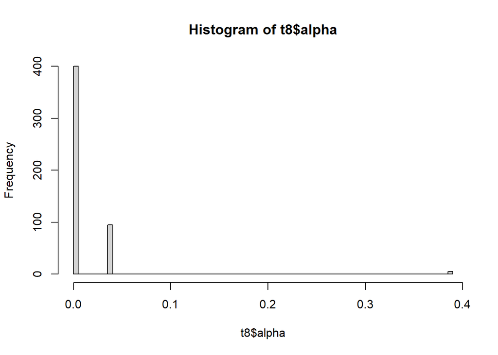

```r
hist(t8$alpha,breaks=100)
```

```r
nrow(t8[t8$alpha>0.,])
```

```
## [1] 100
```

```r
nrow(t8[t8$alpha>0.2,])
```

```
## [1] 5
```

Attaching the allele frequency data to the data frame: `aaf` was calculated above.

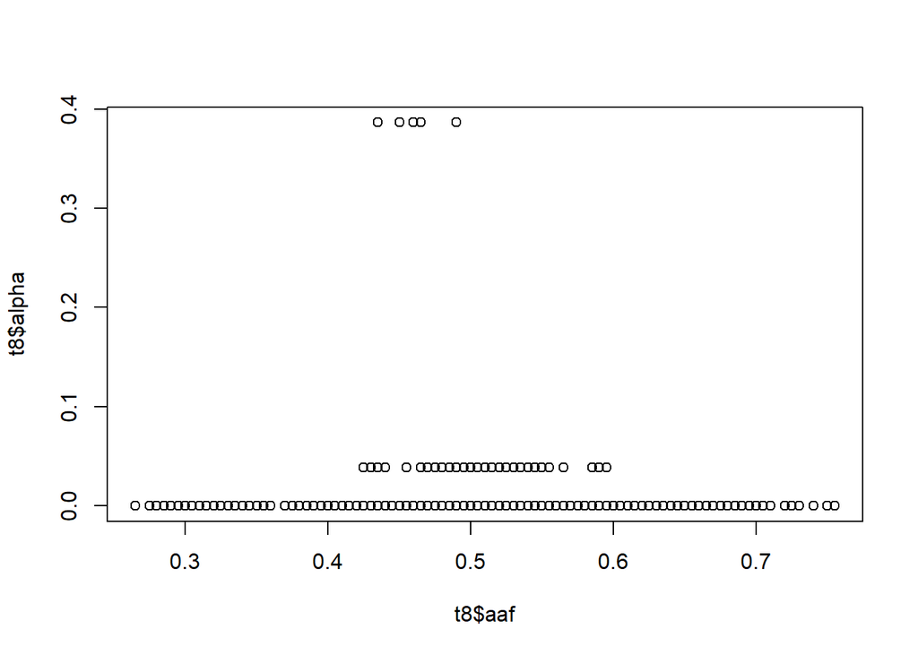

```r
t8$aaf <- aaf
t8$maf <- qgm_maf(aaf)
plot(t8$aaf,t8$alpha)
```

The genic variances for each locus can be calculated assuming HWE frequencies. The total genic variance can be obtained by summing up over all loci, and the fraction contributed by the 5 large SNP can be calculated.

```r
t8$va <- 2*t8$aaf*(1.-t8$aaf)*t8$alpha**2.
head(t8)
```

```
##    name alpha   aaf   maf va
## 1 snp_1     0 0.380 0.380  0
## 2 snp_2     0 0.370 0.370  0
## 3 snp_3     0 0.375 0.375  0
## 4 snp_4     0 0.685 0.315  0
## 5 snp_5     0 0.680 0.320  0
## 6 snp_6     0 0.330 0.330  0
```

## 8.1 Questions

- Q1. Use the code block below to calculate the total genic variance for the trait.
- $\mathbf{Answer.}$ See code block below. The genic variance is 0.441 …

```r
va <- sum(t8$va)
vq <- sum(t8[t8$alpha>0.1,]$va)
va
```

```
## [1] 0.4409115
```

```r
vq/va
```

```
## [1] 0.8401416
```

```r
var(gbv$tbv) # actual variance for comparison
```

```
## [1] 0.5
```

- Q2. How much of the genic variance explained by the 5 large QTL.
- $\mathbf{Answer.}$ … of which 84% is explained by the 5 loci with large effect. (See block above.)
- Q3. How well might the genic variance approximate the true genetic variance for this population?
- $\mathbf{Answer.}$ Very well. The genic variance assumes HWE and linkage equilibrium which is given in the text above. One can test this (see below). It is actually a little on the low side which is due to sampling error. The genic variances would often be assumed to be overestimates of total genetic variance as we might expect negative linkage disequilibrium (i.e. negative covariance) between ‘increasing alleles’ in the presence of any form of selection. However +ve assortative mating (preferential mating of relatives) will tend to increase the variance of the TBV as there will be more homozygotes and -ve assortative mating (avoiding the mating of relatives) will tend to decrease it.
- Q4. How has the SNP design increased the chances of observing a genetic signal in this small data set? (Give a reasoned argument - pros and cons.)
- $\mathbf{Answer.}$ There are various arguments.
  - The causal variants are in the marker set so do not rely on LD to predict effects;
  - Linkage equilibrium in making the allele counts independent;
  - Intermediate allele frequencies to make each locus as informative as possible, so less shrinkage if using Van Raden 1.
  - Perhaps having a few large effects to explain the genetic variance, so they are noticeable even after shrinkage, however GBLUP is indifferent to genetic architecture.
  - Two factors did not help.
    - The relatively large number of SNP loci. But that is why we use GBLUP!
    - HWE: $\mathbf{if}$ the loci are additive then estimates are better if we have more homozygotes and less heterozygotes. Therefore some +ve assortative mating would have helped. Think about it as a regression (it is ridge regression!) you get the best estimate of slope by having a widely spread covariate. If they are not additive then we may introduce some bias in estimating breeding values which will offset the smaller estimation error, which, when we have dominance, depends on estimating allelic substitution effects given the genotype frequencies.

# 9 Deriving the estimates of SNP effects from EBVs

## 9.1 Van Raden Model 1

We will calculate the SNP effects for Van Raden 1 using the formulae given in the lectures by pre-multiplying with $\mathbf{W}_1^T\mathbf{G}_1^{-1}$ and scaling by $\sum_{loci} 2p_j(1-p_j)$ which is calculated above as `cc` (and has value 238.4). We need the inverse of $\mathbf{G}$ and we will use `qgm_solve()` for inversion - it is about twice as fast.

```r
G1inv <- qgm_solve(G1)
t8$b_vr1 <- t(W1)%*%G1inv%*%(gbv$ebv1)
t8$b_vr1 <- t8$b_vr1/cc
head(t8)
```

```
##    name alpha   aaf   maf va        b_vr1
## 1 snp_1     0 0.380 0.380  0 -0.007364822
## 2 snp_2     0 0.370 0.370  0 -0.001047409
## 3 snp_3     0 0.375 0.375  0  0.001472624
## 4 snp_4     0 0.685 0.315  0  0.003631006
## 5 snp_5     0 0.680 0.320  0 -0.003230041
## 6 snp_6     0 0.330 0.330  0  0.006526792
```

The plot shows that some signal is present! However it is weak and is observable since we know the true values! The true values of 0.4 are shrunk to ~ 0.02 (see below). In what follows remember that in real complex traits the known causal variants (if any) explain only a very minor fraction of the genetic variance at best!

- `pch` changes point shape … Google pch in ‘R plot pch’
- `cex` controls point size

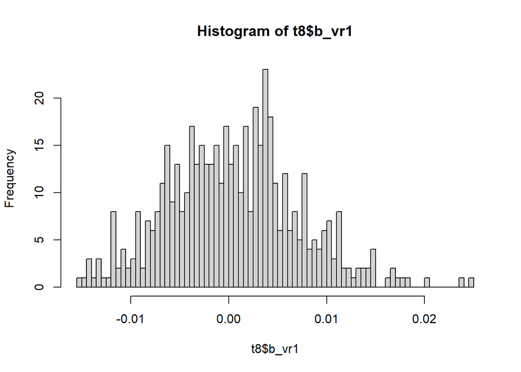

```r
hist(t8$b_vr1,breaks=100)
```

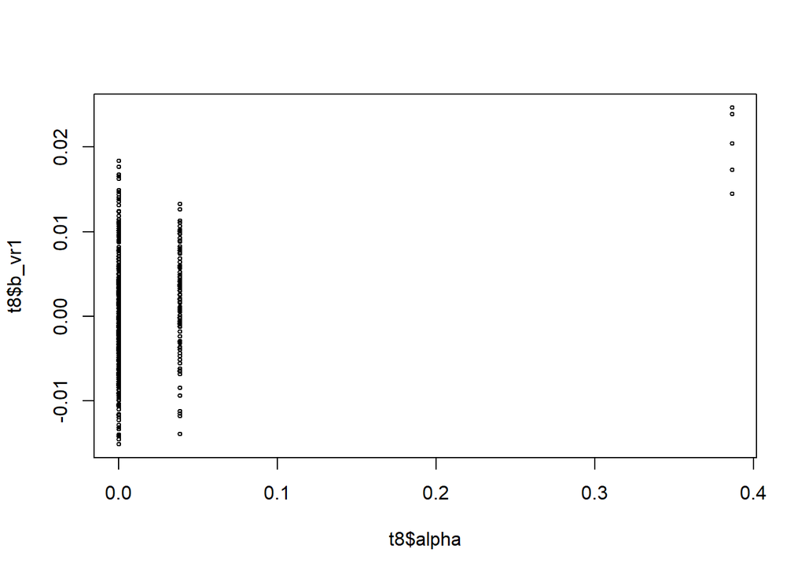

```r
plot(t8$alpha,t8$b_vr1, pch=1, cex =0.5)
```

We can look more closely at the loci with the different classes of loci. The true zero effect and the non zero are separated by `alpha` being < or > 0.01.

```r
mean(t8[t8$alpha<0.01,]$b_vr1)
```

```
## [1] -8.363897e-05
```

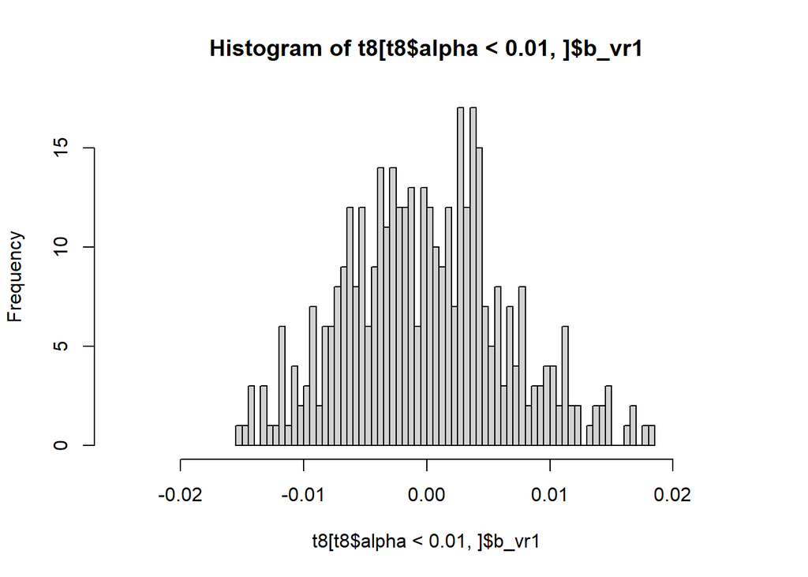

```r
hist(t8[t8$alpha<0.01,]$b_vr1,breaks=50, xlim=c(-0.025,0.025))
```

```r
mean(t8[t8$alpha>0.01,]$b_vr1)
```

```
## [1] 0.002754861
```

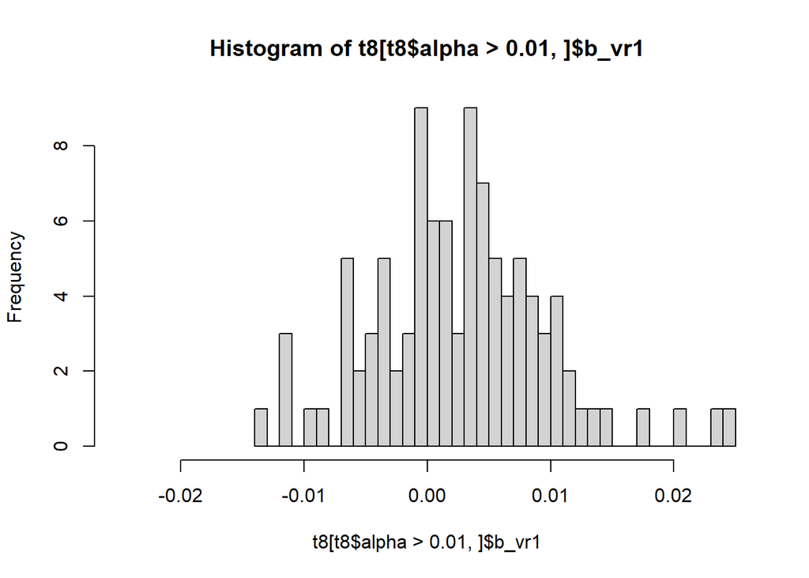

```r
hist(t8[t8$alpha>0.01,]$b_vr1,breaks=50, xlim=c(-0.025,0.025))
```

I have sorted the data frame on absolute values of the estimated SNP effects into descending order (i.e. biggest magnitudes at the top), i.e `order(-abs(t8$bhat_vr1))`, and displayed the first 20 rows. The five large SNP appear in ranks 1, 2, 3, 6 and 15 (and were estimated with the correct sign so are not simply large errors!); all other SNPs in the top 20 have no true effect!

```r
t8[order(-abs(t8$b_vr1)),][1:20,]
```

```
##        name     alpha   aaf   maf         va       b_vr1
## 143 snp_143 0.3864247 0.490 0.490 0.07463214  0.02468257
## 250 snp_250 0.3864247 0.465 0.465 0.07429616  0.02390613
## 73   snp_73 0.3864247 0.450 0.450 0.07391539  0.02045119
## 356 snp_356 0.0000000 0.335 0.335 0.00000000  0.01839860
## 441 snp_441 0.0000000 0.445 0.445 0.00000000  0.01772956
## 466 snp_466 0.3864247 0.460 0.460 0.07418417  0.01731021
## 334 snp_334 0.0000000 0.485 0.485 0.00000000  0.01677044
## 482 snp_482 0.0000000 0.405 0.405 0.00000000  0.01653214
## 458 snp_458 0.0000000 0.550 0.450 0.00000000  0.01627787
## 380 snp_380 0.0000000 0.560 0.440 0.00000000 -0.01513797
## 136 snp_136 0.0000000 0.695 0.305 0.00000000  0.01495526
## 228 snp_228 0.0000000 0.460 0.460 0.00000000  0.01474270
## 257 snp_257 0.0000000 0.505 0.495 0.00000000  0.01472982
## 196 snp_196 0.0000000 0.465 0.465 0.00000000 -0.01454925
## 290 snp_290 0.3864247 0.435 0.435 0.07340022  0.01453844
## 361 snp_361 0.0000000 0.520 0.480 0.00000000  0.01440126
## 347 snp_347 0.0000000 0.690 0.310 0.00000000 -0.01423301
## 480 snp_480 0.0000000 0.650 0.350 0.00000000  0.01411278
## 231 snp_231 0.0000000 0.375 0.375 0.00000000 -0.01410219
## 462 snp_462 0.0000000 0.280 0.280 0.00000000 -0.01401438
```

We can look at the genic variance calculated from the SNP effects - these have been regressed back by random regressions so they are not the same as our SNP effects Tutorial 5!

```r
vg_hat <- sum(2*t8$aaf*(1.-t8$aaf)*t8$b_vr1**2.)
vg_hat
```

```
## [1] 0.0107651
```

The only point of the above is to demonstrate that here we are not explaining very much of the total! There are negative covariances between the SNP effects which is why the EBVs are more accurate than what might be guessed from only 2% of the genic variance is explained by the estimates.

## 9.2 Van Raden Model 2

The SNP effects for Van Raden 2 can be calculated.

```r
G2inv <- qgm_solve(G2)
t8$b_vr2 <- t(W2)%*%G2inv%*%(gbv$ebv2)
t8$b_vr2 <- t8$b_vr2/length(loci)
```

Compare `b_vr1` and `b_vr2` by plotting and using `lm()`

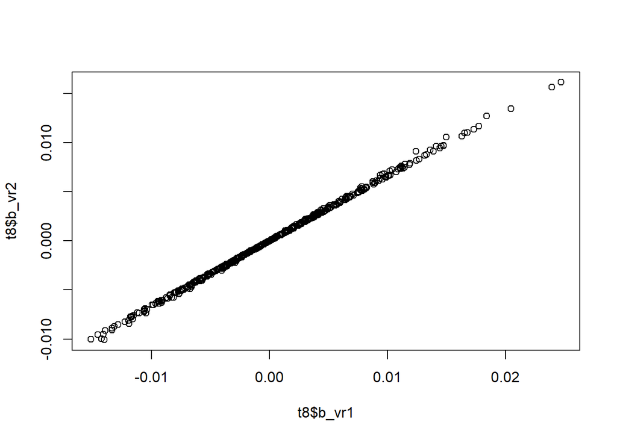

```r
plot(t8$b_vr1,t8$b_vr2)
```

```r
summary( lm(b_vr2 ~1 + b_vr1, data=t8))
```

```
##
## Call:
## lm(formula = b_vr2 ~ 1 + b_vr1, data = t8)
##
## Residuals:
##        Min         1Q     Median         3Q        Max
## -6.998e-04 -5.540e-05  4.040e-06  5.543e-05  8.411e-04
##
## Coefficients:
##               Estimate Std. Error t value Pr(>|t|)
## (Intercept) -6.660e-06  5.343e-06  -1.247    0.213
## b_vr1        6.685e-01  7.971e-04 838.688   <2e-16 ***
## ---
## Signif. codes:  0 '***' 0.001 '**' 0.01 '*' 0.05 '.' 0.1 ' ' 1
##
## Residual standard error: 0.0001192 on 498 degrees of freedom
## Multiple R-squared:  0.9993, Adjusted R-squared:  0.9993
## F-statistic: 7.034e+05 on 1 and 498 DF,  p-value: < 2.2e-16
```

## 9.3 Questions

- Q5. Why are the `b_vr2` and `b_vr1` SNP effects so different in magnitude?
- $\mathbf{Answer.}$ Because `b_vr1` are VR1 and are estimates of allelic substitutions, while `b_vr2` are VR2 and are on a locus s.d. scale. In this example all the loci have nearly intermediate frequency we might expect the slope to be close to $\sqrt{2p(1-p)} = \sqrt{2 \times 0.5 \times0.5} = \sqrt{0.5} = 0.71$.
- Q6. How can this be corrected to make a better comparison?
- $\mathbf{Answer.}$ By dividing the value for `b_vr2` of locus $j$ by $\sqrt{2p_j(1-p_j)}$.
- Q7. Carry out the correction by creating another column in the `t8$b_vr2a` as another column in the data frame and compare `b_vr1` and `b_vr2a`.
- $\mathbf{Answer.}$ See code block below. Not identical but approximately the same. VR1 and VR2 are NOT equivalent models even though the outcomes are similar, so do not expect them to be identical. See the handout on Van Raden Models.

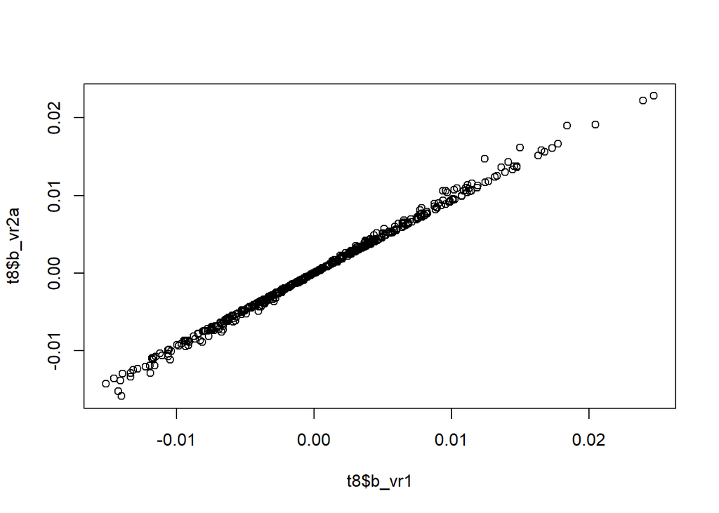

```r
t8$b_vr2a <- t8$b_vr2/sqrt(2.*t8$aaf*(1.-t8$aaf))
plot(t8$b_vr1,t8$b_vr2a)
```

```r
summary( lm(b_vr2a ~1 + b_vr1, data=t8))
```

```
##
## Call:
## lm(formula = b_vr2a ~ 1 + b_vr1, data = t8)
##
## Residuals:
##        Min         1Q     Median         3Q        Max
## -0.0022885 -0.0001468  0.0000174  0.0001456  0.0027270
##
## Coefficients:
##               Estimate Std. Error t value Pr(>|t|)
## (Intercept) -1.801e-05  1.625e-05  -1.108    0.268
## b_vr1        9.677e-01  2.424e-03 399.154   <2e-16 ***
## ---
## Signif. codes:  0 '***' 0.001 '**' 0.01 '*' 0.05 '.' 0.1 ' ' 1
##
## Residual standard error: 0.0003624 on 498 degrees of freedom
## Multiple R-squared:  0.9969, Adjusted R-squared:  0.9969
## F-statistic: 1.593e+05 on 1 and 498 DF,  p-value: < 2.2e-16
```

# 10 Getting marker effects using `asreml()` functions

For reference. We can get the SNP effects directly from `asreml()`. We need to provide the $\mathbf{W}$ matrix appropriately scaled, the $\mathbf{G}$, and the `asr` file - and then extract the information - it seems easier to use the formulae directly. This is illustrated below for Van Raden 1 only, Van Raden 2 follows by analogy. The answers agree to 6 decimal places, and there does not appear to be any advantage in computing time.

- I don’t find this particularly obvious or well-explained in the manual

```r
W1s <- W1/cc
t8.mef <- meff(asr7_1, mef= list(G1="W1s"), effects= ~vm(id, G1))
```

```
## Model fitted using the sigma parameterization.
## ASReml 4.1.0 Fri Feb  4 17:07:38 2022
##           LogLik        Sigma2     DF     wall    cpu
##  1      -48.6703           1.0     99 17:07:38    0.0
```

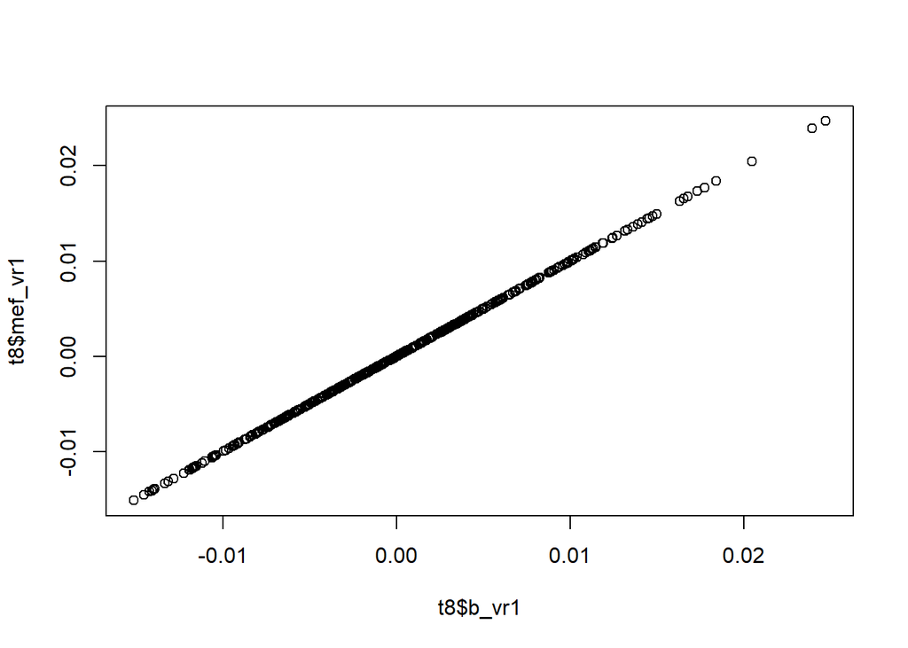

```r
t8$mef_vr1 <- as.vector(t8.mef$meff$`vm(id, G1)`)
plot(t8$b_vr1,t8$mef_vr1)
```

```r
head(t8)
```

```
##    name alpha   aaf   maf va        b_vr1         b_vr2       b_vr2a      mef_vr1
## 1 snp_1     0 0.380 0.380  0 -0.007364822 -0.0049608323 -0.007226898 -0.007365064
## 2 snp_2     0 0.370 0.370  0 -0.001047409 -0.0007039697 -0.001031022 -0.001047439
## 3 snp_3     0 0.375 0.375  0  0.001472624  0.0009894780  0.001445225  0.001472671
## 4 snp_4     0 0.685 0.315  0  0.003631006  0.0025165668  0.003830830  0.003631112
## 5 snp_5     0 0.680 0.320  0 -0.003230041 -0.0022736190 -0.003446460 -0.003230107
## 6 snp_6     0 0.330 0.330  0  0.006526792  0.0045282739  0.006809627  0.006526968
```

The analogy for VR2 is also given below.

```r
W2s <- W2/length(loci)
t8.mef2 <- meff(asr7_2, mef= list(G2="W2s"), effects= ~vm(id, G2))
```

```
## Model fitted using the sigma parameterization.
## ASReml 4.1.0 Fri Feb  4 17:07:38 2022
##           LogLik        Sigma2     DF     wall    cpu
##  1      -48.6981           1.0     99 17:07:38    0.0
```

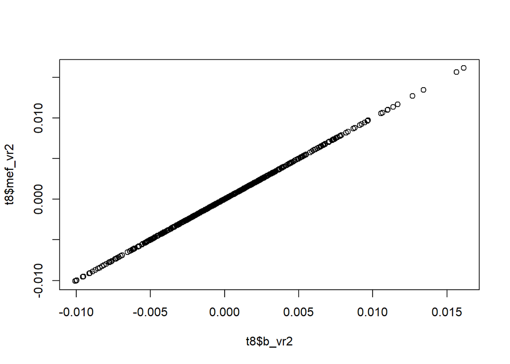

```r
t8$mef_vr2 <- as.vector(t8.mef2$meff$`vm(id, G2)`)
plot(t8$b_vr2,t8$mef_vr2)
```

```r
head(t8)
```

```
##    name alpha   aaf   maf va        b_vr1         b_vr2       b_vr2a      mef_vr1       mef_vr2
## 1 snp_1     0 0.380 0.380  0 -0.007364822 -0.0049608323 -0.007226898 -0.007365064 -0.0049613541
## 2 snp_2     0 0.370 0.370  0 -0.001047409 -0.0007039697 -0.001031022 -0.001047439 -0.0007040345
## 3 snp_3     0 0.375 0.375  0  0.001472624  0.0009894780  0.001445225  0.001472671  0.0009895777
## 4 snp_4     0 0.685 0.315  0  0.003631006  0.0025165668  0.003830830  0.003631112  0.0025167983
## 5 snp_5     0 0.680 0.320  0 -0.003230041 -0.0022736190 -0.003446460 -0.003230107 -0.0022737700
## 6 snp_6     0 0.330 0.330  0  0.006526792  0.0045282739  0.006809627  0.006526968  0.0045286634
```

# 11 Predicting breeding values from SNP effects

## 11.1 With VR1 …

It is feasible that we might have carried out a SNP-BLUP instead of a GBLUP. If so we would have obtained the SNP effects directly. In which case we would have wished to calculate the EBVs. This is done following the SNP BLUP model and $\hat{\mathbf{g}} = \mathbf{W}\hat{\mathbf{b}}$ where the $\mathbf{W}$ and $\hat{\mathbf{b}}$ are the design matrix and solutions according to whether we are doing VR1 or VR2.

So e.g. in VR1 …

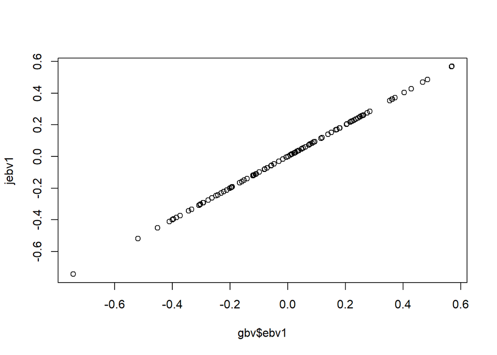

```r
jebv1 <- W1%*%t8$b_vr1
plot(gbv$ebv1,jebv1)
```

```r
summary(lm(jebv1~1+gbv$ebv1))
```

```
##
## Call:
## lm(formula = jebv1 ~ 1 + gbv$ebv1)
##
## Residuals:
##        Min         1Q     Median         3Q        Max
## -2.961e-04 -7.937e-05 -2.582e-06  8.190e-05  2.012e-04
##
## Coefficients:
##               Estimate Std. Error t value Pr(>|t|)
## (Intercept) -3.607e-17  1.047e-05       0        1
## gbv$ebv1     9.992e-01  4.149e-05   24083   <2e-16 ***
## ---
## Signif. codes:  0 '***' 0.001 '**' 0.01 '*' 0.05 '.' 0.1 ' ' 1
##
## Residual standard error: 0.0001047 on 98 degrees of freedom
## Multiple R-squared:      1,  Adjusted R-squared:      1
## F-statistic: 5.8e+08 on 1 and 98 DF,  p-value: < 2.2e-16
```

## 11.2 … and VR2

… repeat for VR2, note that we must use `b_vr2` not `b_vr2a` - it is what the model says!

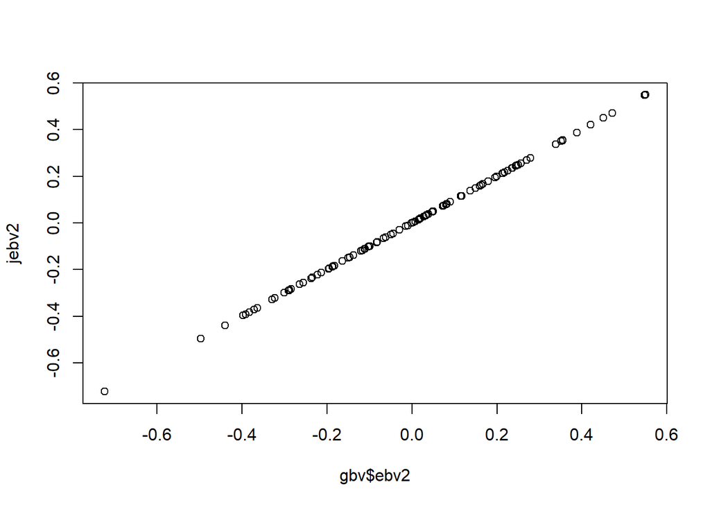

```r
jebv2 <- W2%*%t8$b_vr2
plot(gbv$ebv2,jebv2)
```

## 11.3 Questions

- Q8. Reproduce the TBV from the true SNP alphas …
- $\mathbf{Answer.}$ The point to note here is that the true SNP effects are presented as effects of allelic substitutions as used in VR1, but not VR2. Therefore if you wish to calculate the TBV you use $\mathbf{W}_1$ not $\mathbf{W}_2$

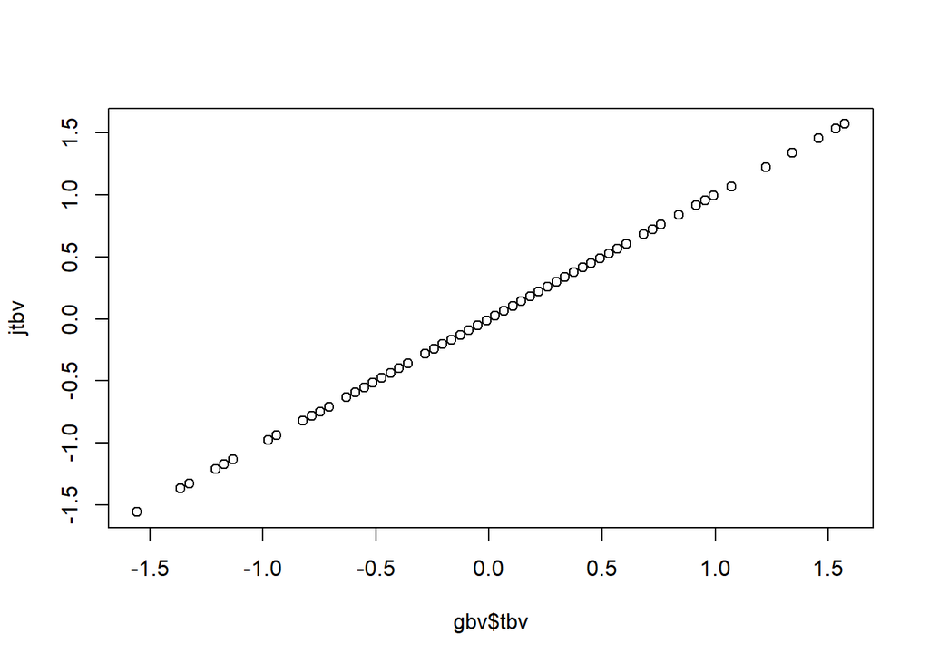

```r
jtbv <- W1%*%t8$alpha
plot(gbv$tbv,jtbv)
```

# 12 Outcomes

- We have seen how to obtain the SNP effects from EBVs calculated by GBLUP (both VR1 and VR2).
- We have compared these to true values since the data is simulated.
- We have calculated genic variances from the true values and the estimates.
- We have calculated EBVs from the SNP effects